# Preprocessing Microbiome Data with Phyloseq

Alicia M. Rich, Ph.D.

2025-06-15

# Preprocessing Overview

In this section we will take raw microbiome count data and turn it into a clean, analysis-ready `phyloseq` object. You will:

## By the end of this stage, you will have one phyloseq object per taxonomic level, each containing:

- A consistent OTU (or Genus/Family…) count table
- Matched sample metadata and taxonomic table
- A pruned phylogenetic tree

# Packages Used

In this script we mostly use the `phyloseq` package, designed for microbiome analysis.

## `phyloseq` Utility

- Integrates OTU/ASV tables, sample metadata, taxonomy, phylogenetic trees, and (optionally) reference sequences in one S4 object.
- Provides convenient methods for merging, pruning, rarefaction, distance calculations, and plotting.
- Under the hood, relies on Bioconductor classes (DataFrames, XStringSets, phylo).

> Note: there is much overlap between `phyloseq`, `microeco`, and `microbiome`, but each makes some steps more streamlined than others, so I prefer to switch between them for different stages of analysis.

We will also use the `treedataverse` package suite for some visualization to check in on our data quality.

## `treedataverse` Utility

The `treedataverse` suite provides tools for managing, sharing, and visualizing phylogenetic trees in R. It builds on the Dataverse platform to store trees (and associated data) in versioned, citable repositories. With `treedataverse`, you can:

- Upload or download phylo objects directly from a Dataverse collection
- Attach rich metadata (e.g. study details, taxon provenance) to each tree
- Track updates and collaborate on tree data with full provenance
- Integrate seamlessly with ggtree and ape for downstream plotting and analysis

### `ggtree` Package within the `treedataverse`

`ggtree` is an extension of `ggplot2` tailored for phylogenetic trees. It lets you:

- Map tree data (branches, node labels, support values) to aesthetic scales
- Annotate clades with heatmaps, bar charts, or tip points (e.g. taxon abundances)
- Collapse or expand subtrees interactively
- Align associated data (e.g. trait matrices) alongside your tree in multi-panel layouts
- Leverage the full grammar of graphics for publication-quality figures

# Helper Functions

I created the functions below because I repeatedly use these code chunks to view summaries of my data after each step of processing.

```r
my_skim <- skim_with(numeric  = sfl(p25 = NULL, p50 = NULL, p75 = NULL))

skim_phyloseq <- function(phyloseq) {
options(
  digits            = 2,
  pillar.sigfig     = 2,
  pillar.subtle_num = TRUE
  )
 skim <- psmelt(phyloseq) %>%
    select(-c(
      subject_certainty,
      subject_studbook_id,
      subject_dam_id,
      subject_sire_id,
      subject_birth_location,
      subject_age)) %>%
    group_by(subject) %>%
    my_skim() %>%
    select(-complete_rate)

 return(skim)
}

view_tree <- function(phyloseq, level = NULL, palette = "rcartocolor::Prism") {
  phylum.cols <-  sample(paletteer::paletteer_d(paste0(palette)), size = length(get_taxa_unique(phyloseq, "Phylum")), replace = TRUE) %>%
    set_names(., get_taxa_unique(phyloseq, "Phylum"))

  tree1 <- ggtree(phyloseq, branch.length = "none", aes(color = Phylum))

  if (is.null(level)) {
    tree2 <- tree1
  } else if (level == "Class") {
    tree2 <- tree1 +
      geom_label(aes(label = Class, fill = Phylum), hjust = -0.05, size = 2, colour = "#000000FF")
  } else if (level == "Phylum") {
    tree2 <- tree1 +
      geom_label(aes(label = Phylum, fill = Phylum), hjust = -0.05, size = 3, colour = "#000000FF")
  }

  tree.out <- tree2 +
    scale_color_manual(values = phylum.cols, na.value = "#00000080") +
    scale_fill_manual( values = alpha(c(phylum.cols), 0.3)) +
    theme_tree(legend.position = "none")

  return(tree.out)
}
```

# Load Data

> Note that I use `.RData` files to load some of the data below. You could load these same objects in the form of more widely applicable files, if you wish (*see below for explaination*).

**What is an .RData file?**

An `.RData` (or sometimes `.rda`) file is R’s native, binary workspace format. When you call `save()` on one or more R objects—data frames, matrices, lists, S4/S3 objects, etc.—R serializes them into a compact, platform-independent file. You can later restore those exact objects (with their names and attributes intact) by calling load(“`your_file.RData`”). Using `.RData` is an efficient way to cache intermediate steps, share processed datasets with collaborators, or speed up analyses by skipping time-consuming recomputation.

```r
tree <- read.tree("microeco/loris/refs_tree.treefile")
seqs <- readDNAStringSet("microeco/loris/refs_aligned_mafft.fasta")
load("microeco/loris/tax_table.RData")
load("microeco/loris/sample_table.RData")
load("microeco/loris/otu_table.RData")
```

## Sample Metadata as Factors

Phyloseq will only capture numeric/factor values (not strings) for the metadata, so we need to reformat our character columns.

```r
sample_data <- sample.table %>%
  arrange(subject, collection_day) %>%
  mutate(subject_certainty       = fct_recode(subject_certainty  , "0" = "no" , "1" = "yes"),
         environment_holding     = fct_recode(environment_holding, "0" = "old", "1" = "new"),
         environment_pair_access = fct_recode(environment_pair_access, "0" = "n", "1" = "y"),
         repro_warb_status       = fct_recode(repro_warb_status, "0" = "anestrus", "1" = "estrus")) %>%
  mutate(across(where(is.character), ~factor(.))) %>%
  mutate(diet_name = fct_inorder(diet_name))
```

## Phyloseq Object

```r
phylo <- phyloseq(
  tax_table(as.matrix(tax.table)),
  otu_table(as.matrix(otu.table), taxa_are_rows = TRUE),
  sample_data(sample_data),
  phy_tree(tree),
  refseq(seqs)
)
```

## Preview Starting Data

```r
skim_phyloseq(phylo)
```

Data summary

| Name | Piped data |
| --- | --- |
| Number of rows | 906576 |
| Number of columns | 87 |
| _______________________ |  |
| Column type frequency: |  |
| character | 9 |
| Date | 1 |
| factor | 6 |
| numeric | 70 |
| ________________________ |  |
| Group variables | subject |

**Variable type: character**

| skim_variable | subject | n_missing | min | max | empty | n_unique | whitespace |
| --- | --- | --- | --- | --- | --- | --- | --- |
| OTU | culi | 0 | 6 | 11 | 0 | 2244 | 0 |
| OTU | warble | 0 | 6 | 11 | 0 | 2244 | 0 |
| Sample | culi | 0 | 10 | 15 | 0 | 175 | 0 |
| Sample | warble | 0 | 10 | 15 | 0 | 229 | 0 |
| Kingdom | culi | 0 | 11 | 11 | 0 | 1 | 0 |
| Kingdom | warble | 0 | 11 | 11 | 0 | 1 | 0 |
| Phylum | culi | 0 | 13 | 29 | 0 | 26 | 0 |
| Phylum | warble | 0 | 13 | 29 | 0 | 26 | 0 |
| Class | culi | 0 | 3 | 26 | 0 | 56 | 0 |
| Class | warble | 0 | 3 | 26 | 0 | 56 | 0 |
| Order | culi | 0 | 3 | 26 | 0 | 128 | 0 |
| Order | warble | 0 | 3 | 26 | 0 | 128 | 0 |
| Family | culi | 0 | 3 | 32 | 0 | 273 | 0 |
| Family | warble | 0 | 3 | 32 | 0 | 273 | 0 |
| Genus | culi | 0 | 3 | 26 | 0 | 925 | 0 |
| Genus | warble | 0 | 3 | 26 | 0 | 925 | 0 |
| Species | culi | 0 | 15 | 46 | 0 | 2244 | 0 |
| Species | warble | 0 | 15 | 46 | 0 | 2244 | 0 |

**Variable type: Date**

| skim_variable | subject | n_missing | min | max | median | n_unique |
| --- | --- | --- | --- | --- | --- | --- |
| collection_date | culi | 0 | 2023-10-26 | 2024-12-14 | 2024-02-04 | 166 |
| collection_date | warble | 0 | 2023-10-26 | 2024-09-15 | 2024-03-26 | 219 |

**Variable type: factor**

| skim_variable | subject | n_missing | ordered | n_unique | top_counts |
| --- | --- | --- | --- | --- | --- |
| subject_sex | culi | 0 | FALSE | 1 | m: 392700, f: 0 |
| subject_sex | warble | 0 | FALSE | 1 | f: 513876, m: 0 |
| subject_day | culi | 0 | FALSE | 166 | cul: 4488, cul: 4488, cul: 4488, cul: 4488 |
| subject_day | warble | 0 | FALSE | 219 | war: 4488, war: 4488, war: 4488, war: 4488 |
| environment_holding | culi | 0 | FALSE | 2 | 0: 246840, 1: 145860 |
| environment_holding | warble | 0 | FALSE | 2 | 1: 302940, 0: 210936 |
| environment_pair_access | culi | 0 | FALSE | 2 | 0: 359040, 1: 33660 |
| environment_pair_access | warble | 0 | FALSE | 2 | 0: 489192, 1: 24684 |
| repro_warb_status | culi | 0 | FALSE | 3 | 0: 296208, pre: 53856, 1: 42636 |
| repro_warb_status | warble | 0 | FALSE | 3 | 0: 235620, pre: 235620, 1: 42636 |
| diet_name | culi | 0 | FALSE | 3 | oat: 249084, bas: 141372, bis: 2244 |
| diet_name | warble | 0 | FALSE | 1 | bas: 513876, oat: 0, bis: 0 |

**Variable type: numeric**

| skim_variable | subject | n_missing | mean | sd | p0 | p100 | hist |
| --- | --- | --- | --- | --- | --- | --- | --- |
| Abundance | culi | 0 | 3.21 | 62.37 | 0.00 | 7168.00 | ▇▁▁▁▁ |
| Abundance | warble | 0 | 2.72 | 56.75 | 0.00 | 8486.00 | ▇▁▁▁▁ |
| collection_day | culi | 0 | 100.13 | 62.10 | 1.00 | 416.00 | ▇▇▂▁▁ |
| collection_day | warble | 0 | 161.90 | 96.25 | 1.00 | 326.00 | ▇▇▇▆▇ |
| bristol_min | culi | 8976 | 3.11 | 1.03 | 0.00 | 6.00 | ▁▂▇▁▂ |
| bristol_min | warble | 0 | 1.00 | 0.00 | 1.00 | 1.00 | ▁▁▇▁▁ |
| bristol_mean | culi | 0 | 3.49 | 1.18 | 0.00 | 6.00 | ▁▃▇▅▂ |
| bristol_mean | warble | 0 | 1.00 | 0.00 | 1.00 | 1.00 | ▁▁▇▁▁ |
| bristol_max | culi | 8976 | 3.85 | 1.56 | 0.00 | 6.00 | ▁▃▇▁▇ |
| bristol_max | warble | 0 | 1.00 | 0.00 | 1.00 | 1.00 | ▁▁▇▁▁ |
| supplement_probiotic | culi | 0 | 0.71 | 0.44 | 0.00 | 1.00 | ▃▁▁▁▇ |
| supplement_probiotic | warble | 0 | 0.00 | 0.00 | 0.00 | 0.00 | ▁▁▇▁▁ |
| supplement_steroid | culi | 0 | 0.69 | 0.43 | 0.00 | 1.00 | ▃▁▂▁▇ |
| supplement_steroid | warble | 0 | 0.00 | 0.00 | 0.00 | 0.00 | ▁▁▇▁▁ |
| supplement_fiber | culi | 0 | 0.00 | 0.00 | 0.00 | 0.00 | ▁▁▇▁▁ |
| supplement_fiber | warble | 0 | 0.00 | 0.00 | 0.00 | 0.00 | ▁▁▇▁▁ |
| supplement_antibiotic | culi | 0 | 0.02 | 0.13 | 0.00 | 1.00 | ▇▁▁▁▁ |
| supplement_antibiotic | warble | 0 | 0.00 | 0.00 | 0.00 | 0.00 | ▁▁▇▁▁ |
| supplement_antidiarrheal | culi | 0 | 0.00 | 0.00 | 0.00 | 0.00 | ▁▁▇▁▁ |
| supplement_antidiarrheal | warble | 0 | 0.00 | 0.00 | 0.00 | 0.00 | ▁▁▇▁▁ |
| diet_Total_total | culi | 0 | 0.60 | 0.04 | 0.54 | 0.73 | ▅▁▇▁▁ |
| diet_Total_total | warble | 0 | 0.54 | 0.00 | 0.54 | 0.54 | ▁▁▇▁▁ |
| diet_Protein_total | culi | 0 | 0.67 | 0.02 | 0.60 | 0.69 | ▁▁▁▇▅ |
| diet_Protein_total | warble | 0 | 0.69 | 0.00 | 0.69 | 0.69 | ▁▁▇▁▁ |
| diet_Fat_total | culi | 0 | 0.62 | 0.01 | 0.61 | 0.70 | ▇▅▁▁▁ |
| diet_Fat_total | warble | 0 | 0.63 | 0.00 | 0.63 | 0.63 | ▁▁▇▁▁ |
| diet_CHO_by_diff_total | culi | 0 | 0.34 | 0.04 | 0.29 | 0.60 | ▅▇▁▁▁ |
| diet_CHO_by_diff_total | warble | 0 | 0.29 | 0.00 | 0.29 | 0.29 | ▁▁▇▁▁ |
| diet_Ash_total | culi | 0 | 1.00 | 0.02 | 0.79 | 1.00 | ▁▁▁▁▇ |
| diet_Ash_total | warble | 0 | 1.00 | 0.00 | 1.00 | 1.00 | ▁▁▇▁▁ |

[output cut: 110 more lines]

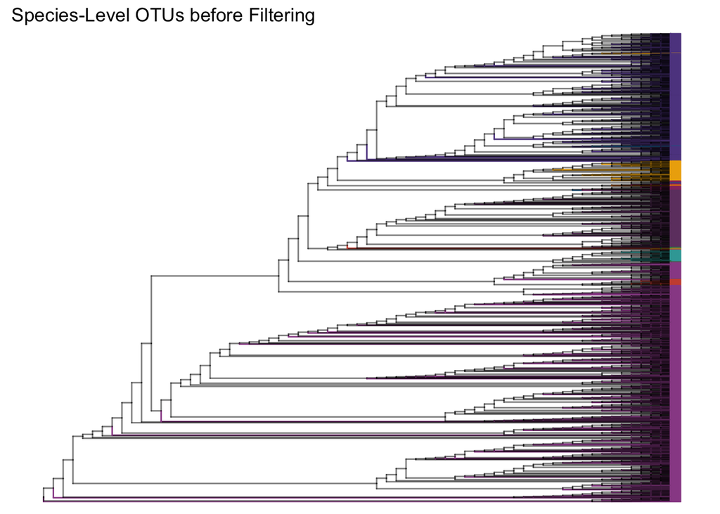

```r
view_tree(phylo) + ggtitle("Species-Level OTUs before Filtering")
```

That looks like some very dense, messy taxonomic data!

# Dereplicate Samples

First we will create a version that merges the replicated samples so that we have one observation per subject per day. This function’s default in phyloseq will aggregate the OTU counts across multiple samples as a sum of reads while taking mean values for everything in the metadata.

> This pooling step creates **one composite sample per subject per day**, avoiding pseudo‐replication in downstream diversity metrics.

```r
phylo_merged <- phylo %>% merge_samples("subject_day")

skim_phyloseq(phylo_merged)
```

Data summary

| Name | Piped data |
| --- | --- |
| Number of rows | 863940 |
| Number of columns | 87 |
| _______________________ |  |
| Column type frequency: |  |
| character | 9 |
| numeric | 77 |
| ________________________ |  |
| Group variables | subject |

**Variable type: character**

| skim_variable | subject | n_missing | min | max | empty | n_unique | whitespace |
| --- | --- | --- | --- | --- | --- | --- | --- |
| OTU | 1 | 0 | 6 | 11 | 0 | 2244 | 0 |
| OTU | 2 | 0 | 6 | 11 | 0 | 2244 | 0 |
| Sample | 1 | 0 | 6 | 8 | 0 | 166 | 0 |
| Sample | 2 | 0 | 8 | 10 | 0 | 219 | 0 |
| Kingdom | 1 | 0 | 11 | 11 | 0 | 1 | 0 |
| Kingdom | 2 | 0 | 11 | 11 | 0 | 1 | 0 |
| Phylum | 1 | 0 | 13 | 29 | 0 | 26 | 0 |
| Phylum | 2 | 0 | 13 | 29 | 0 | 26 | 0 |
| Class | 1 | 0 | 3 | 26 | 0 | 56 | 0 |
| Class | 2 | 0 | 3 | 26 | 0 | 56 | 0 |
| Order | 1 | 0 | 3 | 26 | 0 | 128 | 0 |
| Order | 2 | 0 | 3 | 26 | 0 | 128 | 0 |
| Family | 1 | 0 | 3 | 32 | 0 | 273 | 0 |
| Family | 2 | 0 | 3 | 32 | 0 | 273 | 0 |
| Genus | 1 | 0 | 3 | 26 | 0 | 925 | 0 |
| Genus | 2 | 0 | 3 | 26 | 0 | 925 | 0 |
| Species | 1 | 0 | 15 | 46 | 0 | 2244 | 0 |
| Species | 2 | 0 | 15 | 46 | 0 | 2244 | 0 |

**Variable type: numeric**

| skim_variable | subject | n_missing | mean | sd | p0 | p100 | hist |
| --- | --- | --- | --- | --- | --- | --- | --- |
| Abundance | 1 | 0 | 3.4e+00 | 65.57 | 0.0e+00 | 7.2e+03 | ▇▁▁▁▁ |
| Abundance | 2 | 0 | 2.9e+00 | 58.71 | 0.0e+00 | 8.5e+03 | ▇▁▁▁▁ |
| subject_sex | 1 | 0 | 2.0e+00 | 0.00 | 2.0e+00 | 2.0e+00 | ▁▁▇▁▁ |
| subject_sex | 2 | 0 | 1.0e+00 | 0.00 | 1.0e+00 | 1.0e+00 | ▁▁▇▁▁ |
| subject_day | 1 | 0 | 8.4e+01 | 47.92 | 1.0e+00 | 1.7e+02 | ▇▇▇▇▇ |
| subject_day | 2 | 0 | 2.8e+02 | 63.22 | 1.7e+02 | 3.8e+02 | ▇▇▇▇▇ |
| collection_day | 1 | 0 | 1.0e+02 | 62.09 | 1.0e+00 | 4.2e+02 | ▇▇▂▁▁ |
| collection_day | 2 | 0 | 1.6e+02 | 95.94 | 1.0e+00 | 3.3e+02 | ▇▇▇▆▇ |
| collection_date | 1 | 0 | 2.0e+04 | 62.09 | 2.0e+04 | 2.0e+04 | ▇▇▂▁▁ |
| collection_date | 2 | 0 | 2.0e+04 | 95.94 | 2.0e+04 | 2.0e+04 | ▇▇▇▆▇ |
| environment_holding | 1 | 0 | 1.6e+00 | 0.48 | 1.0e+00 | 2.0e+00 | ▅▁▁▁▇ |
| environment_holding | 2 | 0 | 1.4e+00 | 0.49 | 1.0e+00 | 2.0e+00 | ▇▁▁▁▆ |
| environment_pair_access | 1 | 0 | 1.1e+00 | 0.29 | 1.0e+00 | 2.0e+00 | ▇▁▁▁▁ |
| environment_pair_access | 2 | 0 | 1.1e+00 | 0.22 | 1.0e+00 | 2.0e+00 | ▇▁▁▁▁ |
| repro_warb_status | 1 | 0 | 1.4e+00 | 0.73 | 1.0e+00 | 3.0e+00 | ▇▁▁▁▂ |
| repro_warb_status | 2 | 0 | 2.0e+00 | 0.96 | 1.0e+00 | 3.0e+00 | ▇▁▂▁▇ |
| bristol_min | 1 | 8976 | 3.1e+00 | 1.02 | 0.0e+00 | 6.0e+00 | ▁▂▇▁▂ |
| bristol_min | 2 | 0 | 1.0e+00 | 0.00 | 1.0e+00 | 1.0e+00 | ▁▁▇▁▁ |
| bristol_mean | 1 | 0 | 3.5e+00 | 1.17 | 0.0e+00 | 6.0e+00 | ▁▃▇▃▂ |
| bristol_mean | 2 | 0 | 1.0e+00 | 0.00 | 1.0e+00 | 1.0e+00 | ▁▁▇▁▁ |
| bristol_max | 1 | 8976 | 3.8e+00 | 1.55 | 0.0e+00 | 6.0e+00 | ▁▃▇▁▆ |
| bristol_max | 2 | 0 | 1.0e+00 | 0.00 | 1.0e+00 | 1.0e+00 | ▁▁▇▁▁ |
| supplement_probiotic | 1 | 0 | 7.1e-01 | 0.44 | 0.0e+00 | 1.0e+00 | ▃▁▁▁▇ |
| supplement_probiotic | 2 | 0 | 0.0e+00 | 0.00 | 0.0e+00 | 0.0e+00 | ▁▁▇▁▁ |
| supplement_steroid | 1 | 0 | 7.0e-01 | 0.43 | 0.0e+00 | 1.0e+00 | ▃▁▂▁▇ |
| supplement_steroid | 2 | 0 | 0.0e+00 | 0.00 | 0.0e+00 | 0.0e+00 | ▁▁▇▁▁ |
| supplement_fiber | 1 | 0 | 0.0e+00 | 0.00 | 0.0e+00 | 0.0e+00 | ▁▁▇▁▁ |
| supplement_fiber | 2 | 0 | 0.0e+00 | 0.00 | 0.0e+00 | 0.0e+00 | ▁▁▇▁▁ |
| supplement_antibiotic | 1 | 0 | 2.0e-02 | 0.13 | 0.0e+00 | 1.0e+00 | ▇▁▁▁▁ |
| supplement_antibiotic | 2 | 0 | 0.0e+00 | 0.00 | 0.0e+00 | 0.0e+00 | ▁▁▇▁▁ |

[output cut: 124 more lines]

# Clean up Taxonomy

## Prune Taxa

Drop the OTUs with the lowest abundances to help stabilize diversity estimates and speed up tree operations. We will constrain based on:

1. Total sum of OTU counts across all samples
2. Proportion of samples where OTU is present

```r
# custom function for filtering thresholds

keep_taxa <- function(phyloseq, tax_thresh, samp_thresh) {
  taxa_names(phyloseq)[
  taxa_sums(phyloseq) > tax_thresh &
  apply(otu_table(phyloseq), 1, function(x) sum(x > 0)) > nsamples(phyloseq)*samp_thresh
]
}

report_threshold <- function(phyloseq, keep) {
  cat(paste0(
    "starting with ", ntaxa(phyloseq), " OTUs, discarding ", (ntaxa(phyloseq) - length(keep)), " OTUs, keeping ", length(keep), " OTUs"
  ))
}
```

**First let’s see how many OTUs we lose at different thresholds**

```r
keep_otus <- keep_taxa(phylo_merged, 10, 0.1)
report_threshold(phylo_merged, keep_otus)
```

```
starting with 2244 OTUs, discarding 1419 OTUs, keeping 825 OTUs
```

```r
keep_otus <- keep_taxa(phylo_merged, 5, 0.05)
report_threshold(phylo_merged, keep_otus)
```

```
starting with 2244 OTUs, discarding 1213 OTUs, keeping 1031 OTUs
```

For now, we will remove 1,213 species where the total abundance is less than or equal to 5 or the species only appears in less than 5% of all samples. (*You can change the value in the `keep_taxa` function above to use a higher/lower threshold.*)

```r
phylo_pruned <- prune_taxa(keep_otus, phylo_merged)
skim_phyloseq(phylo_pruned)
```

Data summary

| Name | Piped data |
| --- | --- |
| Number of rows | 396935 |
| Number of columns | 87 |
| _______________________ |  |
| Column type frequency: |  |
| character | 9 |
| numeric | 77 |
| ________________________ |  |
| Group variables | subject |

**Variable type: character**

| skim_variable | subject | n_missing | min | max | empty | n_unique | whitespace |
| --- | --- | --- | --- | --- | --- | --- | --- |
| OTU | 1 | 0 | 6 | 11 | 0 | 1031 | 0 |
| OTU | 2 | 0 | 6 | 11 | 0 | 1031 | 0 |
| Sample | 1 | 0 | 6 | 8 | 0 | 166 | 0 |
| Sample | 2 | 0 | 8 | 10 | 0 | 219 | 0 |
| Kingdom | 1 | 0 | 11 | 11 | 0 | 1 | 0 |
| Kingdom | 2 | 0 | 11 | 11 | 0 | 1 | 0 |
| Phylum | 1 | 0 | 13 | 22 | 0 | 21 | 0 |
| Phylum | 2 | 0 | 13 | 22 | 0 | 21 | 0 |
| Class | 1 | 0 | 3 | 24 | 0 | 42 | 0 |
| Class | 2 | 0 | 3 | 24 | 0 | 42 | 0 |
| Order | 1 | 0 | 3 | 24 | 0 | 76 | 0 |
| Order | 2 | 0 | 3 | 24 | 0 | 76 | 0 |
| Family | 1 | 0 | 3 | 32 | 0 | 156 | 0 |
| Family | 2 | 0 | 3 | 32 | 0 | 156 | 0 |
| Genus | 1 | 0 | 3 | 25 | 0 | 466 | 0 |
| Genus | 2 | 0 | 3 | 25 | 0 | 466 | 0 |
| Species | 1 | 0 | 15 | 46 | 0 | 1031 | 0 |
| Species | 2 | 0 | 15 | 46 | 0 | 1031 | 0 |

**Variable type: numeric**

| skim_variable | subject | n_missing | mean | sd | p0 | p100 | hist |
| --- | --- | --- | --- | --- | --- | --- | --- |
| Abundance | 1 | 0 | 7.3e+00 | 96.59 | 0.0e+00 | 7.2e+03 | ▇▁▁▁▁ |
| Abundance | 2 | 0 | 6.2e+00 | 86.49 | 0.0e+00 | 8.5e+03 | ▇▁▁▁▁ |
| subject_sex | 1 | 0 | 2.0e+00 | 0.00 | 2.0e+00 | 2.0e+00 | ▁▁▇▁▁ |
| subject_sex | 2 | 0 | 1.0e+00 | 0.00 | 1.0e+00 | 1.0e+00 | ▁▁▇▁▁ |
| subject_day | 1 | 0 | 8.4e+01 | 47.92 | 1.0e+00 | 1.7e+02 | ▇▇▇▇▇ |
| subject_day | 2 | 0 | 2.8e+02 | 63.22 | 1.7e+02 | 3.8e+02 | ▇▇▇▇▇ |
| collection_day | 1 | 0 | 1.0e+02 | 62.09 | 1.0e+00 | 4.2e+02 | ▇▇▂▁▁ |
| collection_day | 2 | 0 | 1.6e+02 | 95.94 | 1.0e+00 | 3.3e+02 | ▇▇▇▆▇ |
| collection_date | 1 | 0 | 2.0e+04 | 62.09 | 2.0e+04 | 2.0e+04 | ▇▇▂▁▁ |
| collection_date | 2 | 0 | 2.0e+04 | 95.94 | 2.0e+04 | 2.0e+04 | ▇▇▇▆▇ |
| environment_holding | 1 | 0 | 1.6e+00 | 0.48 | 1.0e+00 | 2.0e+00 | ▅▁▁▁▇ |
| environment_holding | 2 | 0 | 1.4e+00 | 0.49 | 1.0e+00 | 2.0e+00 | ▇▁▁▁▆ |
| environment_pair_access | 1 | 0 | 1.1e+00 | 0.29 | 1.0e+00 | 2.0e+00 | ▇▁▁▁▁ |
| environment_pair_access | 2 | 0 | 1.1e+00 | 0.22 | 1.0e+00 | 2.0e+00 | ▇▁▁▁▁ |
| repro_warb_status | 1 | 0 | 1.4e+00 | 0.73 | 1.0e+00 | 3.0e+00 | ▇▁▁▁▂ |
| repro_warb_status | 2 | 0 | 2.0e+00 | 0.96 | 1.0e+00 | 3.0e+00 | ▇▁▂▁▇ |
| bristol_min | 1 | 4124 | 3.1e+00 | 1.02 | 0.0e+00 | 6.0e+00 | ▁▂▇▁▂ |
| bristol_min | 2 | 0 | 1.0e+00 | 0.00 | 1.0e+00 | 1.0e+00 | ▁▁▇▁▁ |
| bristol_mean | 1 | 0 | 3.5e+00 | 1.17 | 0.0e+00 | 6.0e+00 | ▁▃▇▃▂ |
| bristol_mean | 2 | 0 | 1.0e+00 | 0.00 | 1.0e+00 | 1.0e+00 | ▁▁▇▁▁ |
| bristol_max | 1 | 4124 | 3.8e+00 | 1.55 | 0.0e+00 | 6.0e+00 | ▁▃▇▁▆ |
| bristol_max | 2 | 0 | 1.0e+00 | 0.00 | 1.0e+00 | 1.0e+00 | ▁▁▇▁▁ |
| supplement_probiotic | 1 | 0 | 7.1e-01 | 0.44 | 0.0e+00 | 1.0e+00 | ▃▁▁▁▇ |
| supplement_probiotic | 2 | 0 | 0.0e+00 | 0.00 | 0.0e+00 | 0.0e+00 | ▁▁▇▁▁ |
| supplement_steroid | 1 | 0 | 7.0e-01 | 0.43 | 0.0e+00 | 1.0e+00 | ▃▁▂▁▇ |
| supplement_steroid | 2 | 0 | 0.0e+00 | 0.00 | 0.0e+00 | 0.0e+00 | ▁▁▇▁▁ |
| supplement_fiber | 1 | 0 | 0.0e+00 | 0.00 | 0.0e+00 | 0.0e+00 | ▁▁▇▁▁ |
| supplement_fiber | 2 | 0 | 0.0e+00 | 0.00 | 0.0e+00 | 0.0e+00 | ▁▁▇▁▁ |
| supplement_antibiotic | 1 | 0 | 2.0e-02 | 0.13 | 0.0e+00 | 1.0e+00 | ▇▁▁▁▁ |
| supplement_antibiotic | 2 | 0 | 0.0e+00 | 0.00 | 0.0e+00 | 0.0e+00 | ▁▁▇▁▁ |

[output cut: 124 more lines]

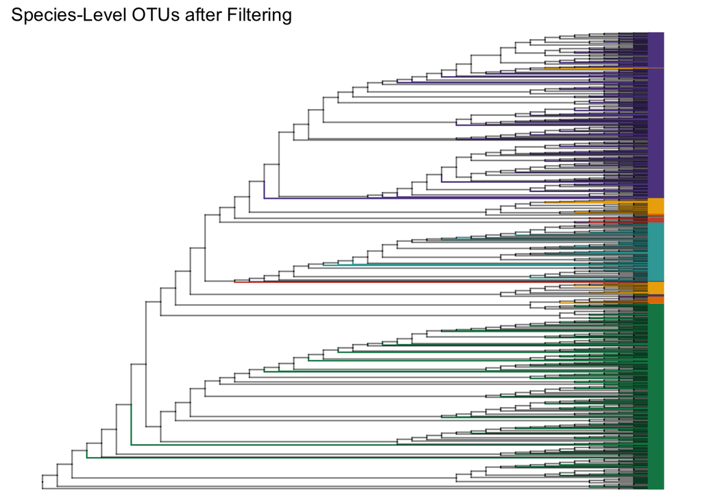

```r
view_tree(phylo_pruned) + ggtitle("Species-Level OTUs after Filtering")
```

## Collapse Taxa to Genus Level

Collapsing at genus level reduces complexity and allows genus‐scale ecological patterns to emerge with less interference from random error at the species-assignment level.

```r
phylo_genus <- phylo_pruned %>% tax_glom("Genus")
skim_phyloseq(phylo_genus)
```

Data summary

| Name | Piped data |
| --- | --- |
| Number of rows | 180180 |
| Number of columns | 86 |
| _______________________ |  |
| Column type frequency: |  |
| character | 8 |
| numeric | 77 |
| ________________________ |  |
| Group variables | subject |

**Variable type: character**

| skim_variable | subject | n_missing | min | max | empty | n_unique | whitespace |
| --- | --- | --- | --- | --- | --- | --- | --- |
| OTU | 1 | 0 | 6 | 11 | 0 | 468 | 0 |
| OTU | 2 | 0 | 6 | 11 | 0 | 468 | 0 |
| Sample | 1 | 0 | 6 | 8 | 0 | 166 | 0 |
| Sample | 2 | 0 | 8 | 10 | 0 | 219 | 0 |
| Kingdom | 1 | 0 | 11 | 11 | 0 | 1 | 0 |
| Kingdom | 2 | 0 | 11 | 11 | 0 | 1 | 0 |
| Phylum | 1 | 0 | 13 | 22 | 0 | 21 | 0 |
| Phylum | 2 | 0 | 13 | 22 | 0 | 21 | 0 |
| Class | 1 | 0 | 3 | 24 | 0 | 42 | 0 |
| Class | 2 | 0 | 3 | 24 | 0 | 42 | 0 |
| Order | 1 | 0 | 3 | 24 | 0 | 76 | 0 |
| Order | 2 | 0 | 3 | 24 | 0 | 76 | 0 |
| Family | 1 | 0 | 3 | 32 | 0 | 156 | 0 |
| Family | 2 | 0 | 3 | 32 | 0 | 156 | 0 |
| Genus | 1 | 0 | 3 | 25 | 0 | 466 | 0 |
| Genus | 2 | 0 | 3 | 25 | 0 | 466 | 0 |

**Variable type: numeric**

| skim_variable | subject | n_missing | mean | sd | p0 | p100 | hist |
| --- | --- | --- | --- | --- | --- | --- | --- |
| Abundance | 1 | 0 | 1.6e+01 | 164.53 | 0.0e+00 | 7.8e+03 | ▇▁▁▁▁ |
| Abundance | 2 | 0 | 1.4e+01 | 146.51 | 0.0e+00 | 9.2e+03 | ▇▁▁▁▁ |
| subject_sex | 1 | 0 | 2.0e+00 | 0.00 | 2.0e+00 | 2.0e+00 | ▁▁▇▁▁ |
| subject_sex | 2 | 0 | 1.0e+00 | 0.00 | 1.0e+00 | 1.0e+00 | ▁▁▇▁▁ |
| subject_day | 1 | 0 | 8.4e+01 | 47.92 | 1.0e+00 | 1.7e+02 | ▇▇▇▇▇ |
| subject_day | 2 | 0 | 2.8e+02 | 63.22 | 1.7e+02 | 3.8e+02 | ▇▇▇▇▇ |
| collection_day | 1 | 0 | 1.0e+02 | 62.09 | 1.0e+00 | 4.2e+02 | ▇▇▂▁▁ |
| collection_day | 2 | 0 | 1.6e+02 | 95.94 | 1.0e+00 | 3.3e+02 | ▇▇▇▆▇ |
| collection_date | 1 | 0 | 2.0e+04 | 62.09 | 2.0e+04 | 2.0e+04 | ▇▇▂▁▁ |
| collection_date | 2 | 0 | 2.0e+04 | 95.94 | 2.0e+04 | 2.0e+04 | ▇▇▇▆▇ |
| environment_holding | 1 | 0 | 1.6e+00 | 0.48 | 1.0e+00 | 2.0e+00 | ▅▁▁▁▇ |
| environment_holding | 2 | 0 | 1.4e+00 | 0.49 | 1.0e+00 | 2.0e+00 | ▇▁▁▁▆ |
| environment_pair_access | 1 | 0 | 1.1e+00 | 0.29 | 1.0e+00 | 2.0e+00 | ▇▁▁▁▁ |
| environment_pair_access | 2 | 0 | 1.1e+00 | 0.22 | 1.0e+00 | 2.0e+00 | ▇▁▁▁▁ |
| repro_warb_status | 1 | 0 | 1.4e+00 | 0.73 | 1.0e+00 | 3.0e+00 | ▇▁▁▁▂ |
| repro_warb_status | 2 | 0 | 2.0e+00 | 0.96 | 1.0e+00 | 3.0e+00 | ▇▁▂▁▇ |
| bristol_min | 1 | 1872 | 3.1e+00 | 1.02 | 0.0e+00 | 6.0e+00 | ▁▂▇▁▂ |
| bristol_min | 2 | 0 | 1.0e+00 | 0.00 | 1.0e+00 | 1.0e+00 | ▁▁▇▁▁ |
| bristol_mean | 1 | 0 | 3.5e+00 | 1.17 | 0.0e+00 | 6.0e+00 | ▁▃▇▃▂ |
| bristol_mean | 2 | 0 | 1.0e+00 | 0.00 | 1.0e+00 | 1.0e+00 | ▁▁▇▁▁ |
| bristol_max | 1 | 1872 | 3.8e+00 | 1.55 | 0.0e+00 | 6.0e+00 | ▁▃▇▁▆ |
| bristol_max | 2 | 0 | 1.0e+00 | 0.00 | 1.0e+00 | 1.0e+00 | ▁▁▇▁▁ |
| supplement_probiotic | 1 | 0 | 7.1e-01 | 0.44 | 0.0e+00 | 1.0e+00 | ▃▁▁▁▇ |
| supplement_probiotic | 2 | 0 | 0.0e+00 | 0.00 | 0.0e+00 | 0.0e+00 | ▁▁▇▁▁ |
| supplement_steroid | 1 | 0 | 7.0e-01 | 0.43 | 0.0e+00 | 1.0e+00 | ▃▁▂▁▇ |
| supplement_steroid | 2 | 0 | 0.0e+00 | 0.00 | 0.0e+00 | 0.0e+00 | ▁▁▇▁▁ |
| supplement_fiber | 1 | 0 | 0.0e+00 | 0.00 | 0.0e+00 | 0.0e+00 | ▁▁▇▁▁ |
| supplement_fiber | 2 | 0 | 0.0e+00 | 0.00 | 0.0e+00 | 0.0e+00 | ▁▁▇▁▁ |
| supplement_antibiotic | 1 | 0 | 2.0e-02 | 0.13 | 0.0e+00 | 1.0e+00 | ▇▁▁▁▁ |
| supplement_antibiotic | 2 | 0 | 0.0e+00 | 0.00 | 0.0e+00 | 0.0e+00 | ▁▁▇▁▁ |

[output cut: 124 more lines]

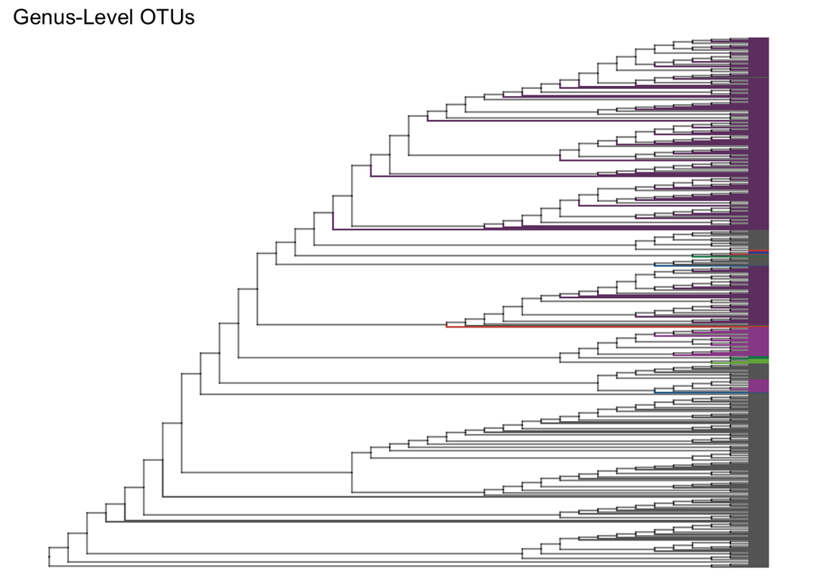

```r
view_tree(phylo_genus) + ggtitle("Genus-Level OTUs")
```

## Another Pruning Check

Let’s look at our OTUs now that we merged to the Genus level and consider filtering to a stricter threshold at this level.

```r
keep_genera <- keep_taxa(phylo_genus, 10, 0.1)
report_threshold(phylo_genus, keep_genera)
```

```
starting with 468 OTUs, discarding 114 OTUs, keeping 354 OTUs
```

Let’s do one more pruning step to only keep the genera with total abundances greater than 10 and presence in at least 10% of all samples (354 genera total).

```r
phylo_clean <- prune_taxa(keep_genera, phylo_genus)
skim_phyloseq(phylo_clean)
```

Data summary

| Name | Piped data |
| --- | --- |
| Number of rows | 136290 |
| Number of columns | 86 |
| _______________________ |  |
| Column type frequency: |  |
| character | 8 |
| numeric | 77 |
| ________________________ |  |
| Group variables | subject |

**Variable type: character**

| skim_variable | subject | n_missing | min | max | empty | n_unique | whitespace |
| --- | --- | --- | --- | --- | --- | --- | --- |
| OTU | 1 | 0 | 6 | 11 | 0 | 354 | 0 |
| OTU | 2 | 0 | 6 | 11 | 0 | 354 | 0 |
| Sample | 1 | 0 | 6 | 8 | 0 | 166 | 0 |
| Sample | 2 | 0 | 8 | 10 | 0 | 219 | 0 |
| Kingdom | 1 | 0 | 11 | 11 | 0 | 1 | 0 |
| Kingdom | 2 | 0 | 11 | 11 | 0 | 1 | 0 |
| Phylum | 1 | 0 | 13 | 22 | 0 | 18 | 0 |
| Phylum | 2 | 0 | 13 | 22 | 0 | 18 | 0 |
| Class | 1 | 0 | 3 | 24 | 0 | 34 | 0 |
| Class | 2 | 0 | 3 | 24 | 0 | 34 | 0 |
| Order | 1 | 0 | 3 | 24 | 0 | 64 | 0 |
| Order | 2 | 0 | 3 | 24 | 0 | 64 | 0 |
| Family | 1 | 0 | 3 | 25 | 0 | 128 | 0 |
| Family | 2 | 0 | 3 | 25 | 0 | 128 | 0 |
| Genus | 1 | 0 | 3 | 25 | 0 | 352 | 0 |
| Genus | 2 | 0 | 3 | 25 | 0 | 352 | 0 |

**Variable type: numeric**

[output not shown]

[output cut: 124 more lines]

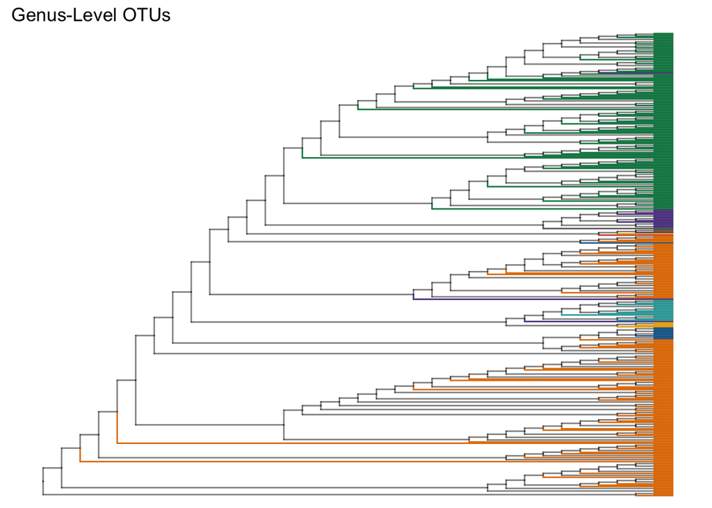

```r
view_tree(phylo_clean) + ggtitle("Genus-Level OTUs")
```

## Extract and Save Clean Phyloseq Objects

Exporting intermediate objects saves time if you need to re‐run later steps without re‐processing.

```r
phylo_melt_clean     <- psmelt(phylo_clean)
clean_tree           <- phy_tree(phylo_clean)
save(phylo_clean     , file = "microeco/loris/phyloseq_genus.RData")
save(clean_tree      , file = "microeco/loris/tree_genus.RData")
save(phylo_melt_clean, file = "microeco/loris/phyloseq_melt_genus.RData")
```

# Subset Additional Taxonomic Levels

Working at multiple ranks lets you compare community structure from broad (Phylum) to fine (Genus) scales in the same pipeline.

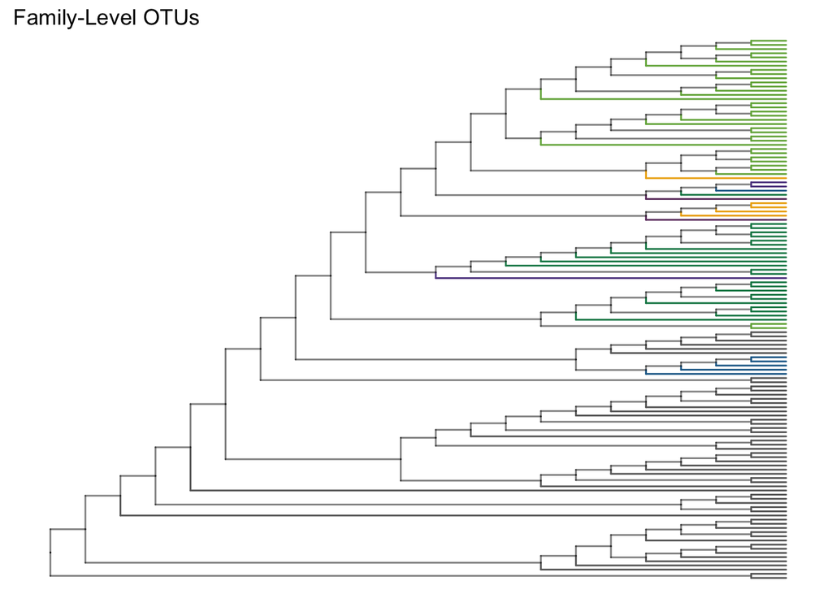

```r
fam_phylo <- phylo_clean %>% tax_glom("Family")
ord_phylo <- phylo_clean %>% tax_glom("Order")
cla_phylo <- phylo_clean %>% tax_glom("Class")
phy_phylo <- phylo_clean %>% tax_glom("Phylum")

view_tree(fam_phylo) + ggtitle("Family-Level OTUs")
```

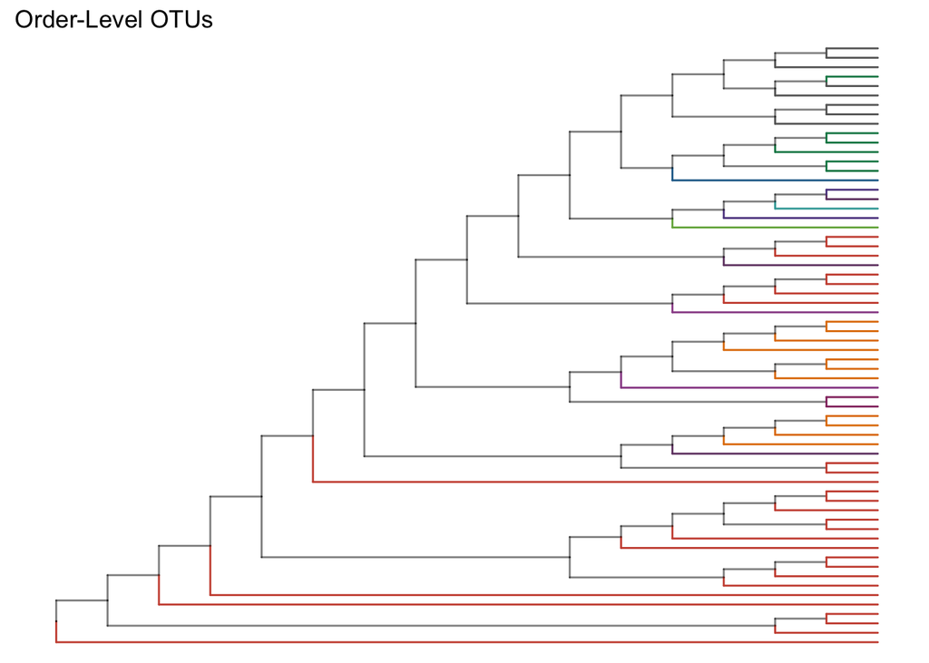

```r
view_tree(ord_phylo) + ggtitle("Order-Level OTUs")
```

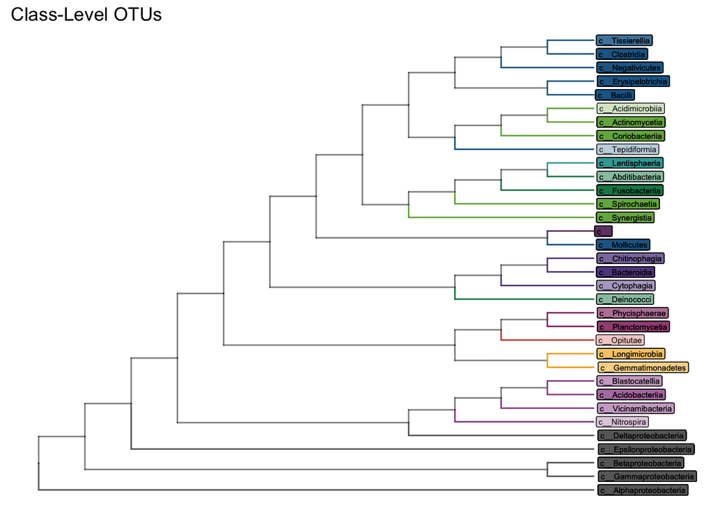

```r
view_tree(cla_phylo, "Class") + ggtitle("Class-Level OTUs") +
      coord_cartesian(clip = "off") +
      theme(plot.margin = margin(5, 65, 5, 5, "pt"))
```

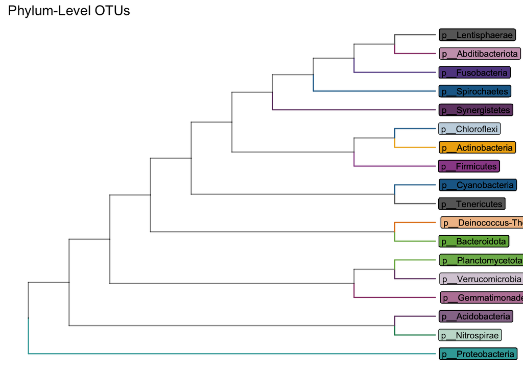

```r
view_tree(phy_phylo, "Phylum") + ggtitle("Phylum-Level OTUs") +
      coord_cartesian(clip = "off") +
      theme(plot.margin = margin(5, 65, 5, 5, "pt"))
```

## Extract and Save for Other Levels

```r
fam_phylo_melt     <- psmelt(fam_phylo)
ord_phylo_melt     <- psmelt(ord_phylo)
cla_phylo_melt     <- psmelt(cla_phylo)
phy_phylo_melt     <- psmelt(phy_phylo)

fam_tree           <- phy_tree(fam_phylo)
ord_tree           <- phy_tree(ord_phylo)
cla_tree           <- phy_tree(cla_phylo)
phy_tree           <- phy_tree(phy_phylo)

save(fam_phylo     , file = "microeco/loris/phyloseq_family.RData")
save(ord_phylo     , file = "microeco/loris/phyloseq_order.RData")
save(cla_phylo     , file = "microeco/loris/phyloseq_class.RData")
save(phy_phylo     , file = "microeco/loris/phyloseq_phylum.RData")

save(fam_tree      , file = "microeco/loris/tree_family.RData")
save(ord_tree      , file = "microeco/loris/tree_order.RData")
save(cla_tree      , file = "microeco/loris/tree_class.RData")
save(phy_tree      , file = "microeco/loris/tree_phylum.RData")

save(fam_phylo_melt, file = "microeco/loris/phyloseq_melt_family.RData")
save(ord_phylo_melt, file = "microeco/loris/phyloseq_melt_order.RData")
save(cla_phylo_melt, file = "microeco/loris/phyloseq_melt_class.RData")
save(phy_phylo_melt, file = "microeco/loris/phyloseq_melt_phylum.RData")
```

# Next Steps

In the [`microbiome_metrics` tutorial](https://rich-molecular-health-lab.github.io/tutorials/microbiome_metrics.html) you will learn how to choose and apply rarefaction or relative-abundance normalization, and then calculate fundamental diversity statistics (α-diversity indices, β-diversity distances, UniFrac, etc.). Refer to that section to decide when and how to rarefy your merged tables, or to work directly on normalized counts for non-phylogenetic metrics.